# Imputación de datos faltantes en base de datos de cervecerías

Daniel Navarro

2025-08-03

# Objetivo

Para revisar una imputación de variables múltiples con equaciones en cadena tomamos una base de datos de Kaggle https://www.kaggle.com/datasets/nickhould/craft-cans/data que contiene dos bases de datos con 2410 diferentes cervezas y 558 en la base de datos de fabricantes en los Estados Unidos.

Las bases de datos están incompletas, faltan 1067 datos distribuidos en diferentes campos de las cervezas y 0 en los de fabricantes.

Se describe a continuación las bases de datos, abv es el contenido de alcohol por volumen, ibu es la unidad internacional de sabor amargo, el resto de las variables están bien identificadas:

```r
summary(original_beers)
```

```
##        X               abv               ibu               id
##  Min.   :   0.0   Min.   :0.00100   Min.   :  4.00   Min.   :   1.0
##  1st Qu.: 602.2   1st Qu.:0.05000   1st Qu.: 21.00   1st Qu.: 808.2
##  Median :1204.5   Median :0.05600   Median : 35.00   Median :1453.5
##  Mean   :1204.5   Mean   :0.05977   Mean   : 42.71   Mean   :1431.1
##  3rd Qu.:1806.8   3rd Qu.:0.06700   3rd Qu.: 64.00   3rd Qu.:2075.8
##  Max.   :2409.0   Max.   :0.12800   Max.   :138.00   Max.   :2692.0
##                   NA's   :62        NA's   :1005
##      name              style             brewery_id        ounces
##  Length:2410        Length:2410        Min.   :  0.0   Min.   : 8.40
##  Class :character   Class :character   1st Qu.: 93.0   1st Qu.:12.00
##  Mode  :character   Mode  :character   Median :205.0   Median :12.00
##                                        Mean   :231.7   Mean   :13.59
##                                        3rd Qu.:366.0   3rd Qu.:16.00
##                                        Max.   :557.0   Max.   :32.00
##
```

```r
summary(original_breweries)
```

```
##        X             name               city              state
##  Min.   :  0.0   Length:558         Length:558         Length:558
##  1st Qu.:139.2   Class :character   Class :character   Class :character
##  Median :278.5   Mode  :character   Mode  :character   Mode  :character
##  Mean   :278.5
##  3rd Qu.:417.8
##  Max.   :557.0
```

# Imputación de datos

Revisamos cómo están distribuidos los datos faltantes en la base de datos de cervezas, beers.

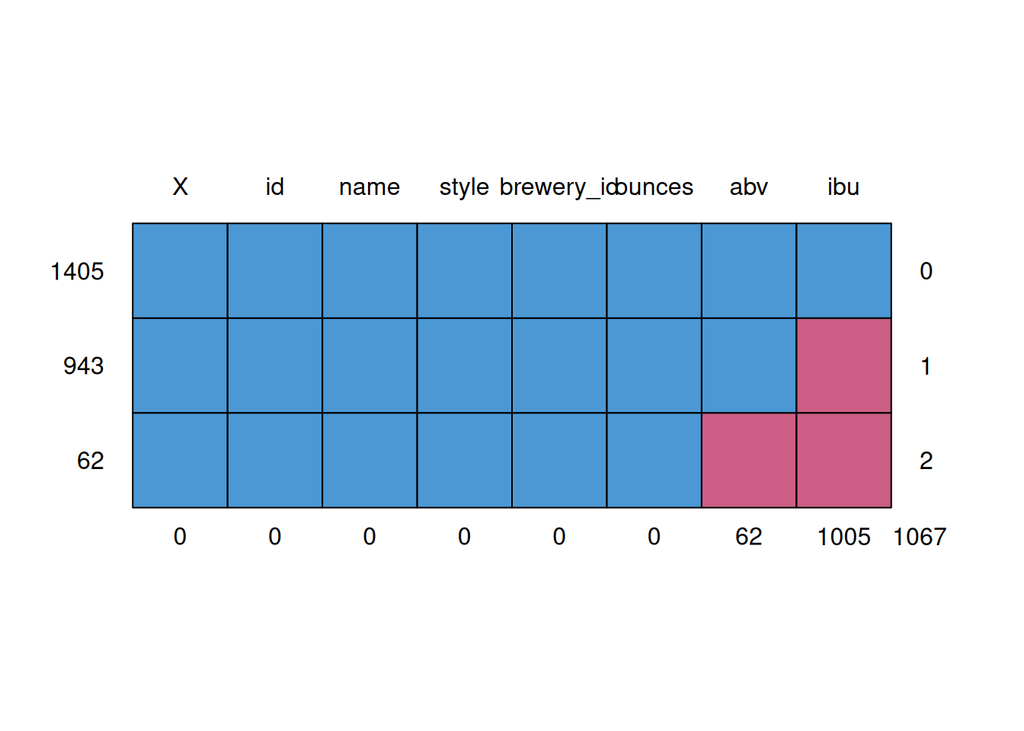

```
##      X id name style brewery_id ounces abv  ibu
## 1405 1  1    1     1          1      1   1    1    0
## 943  1  1    1     1          1      1   1    0    1
## 62   1  1    1     1          1      1   0    0    2
##      0  0    0     0          0      0  62 1005 1067
```

```r
md.pattern(original_beers)
```

Solo faltan datos en las variables abv e ibu, 943 líneas carecen solo de ibu y 62 de ambas variables, abv e ibu.

# Imputación simple utilizando la media

Esta es la práctica común de usar la media de los datos existentes en los datos faltantes.

```r
beers_completed_mean <- original_beers
imp_mean <- mice(beers_completed_mean, method = 'mean', m = 1, maxit = 1)
beers_completed_mean <- complete(imp_mean)
summary(beers_completed_mean)
```

```
##        X               abv               ibu               id
##  Min.   :   0.0   Min.   :0.00100   Min.   :  4.00   Min.   :   1.0
##  1st Qu.: 602.2   1st Qu.:0.05000   1st Qu.: 30.00   1st Qu.: 808.2
##  Median :1204.5   Median :0.05700   Median : 42.71   Median :1453.5
##  Mean   :1204.5   Mean   :0.05977   Mean   : 42.71   Mean   :1431.1
##  3rd Qu.:1806.8   3rd Qu.:0.06700   3rd Qu.: 42.71   3rd Qu.:2075.8
##  Max.   :2409.0   Max.   :0.12800   Max.   :138.00   Max.   :2692.0
##      name              style             brewery_id        ounces
##  Length:2410        Length:2410        Min.   :  0.0   Min.   : 8.40
##  Class :character   Class :character   1st Qu.: 93.0   1st Qu.:12.00
##  Mode  :character   Mode  :character   Median :205.0   Median :12.00
##                                        Mean   :231.7   Mean   :13.59
##                                        3rd Qu.:366.0   3rd Qu.:16.00
##                                        Max.   :557.0   Max.   :32.00
```

Al completar los datos faltantes con la media, se ha completado en una acción todos los datos faltantes en la base de datos.

Al comparar las densidades de ambas variables, antes y después de imputar los datos con la media, abv es consistente con los datos originales, sin embargo ibu está demasiado centrada. Este es un efecto del uso del promedio en casi la mitad de todas las líneas de la variable ibu, así que la media no es una forma balanceada de completar estos datos.

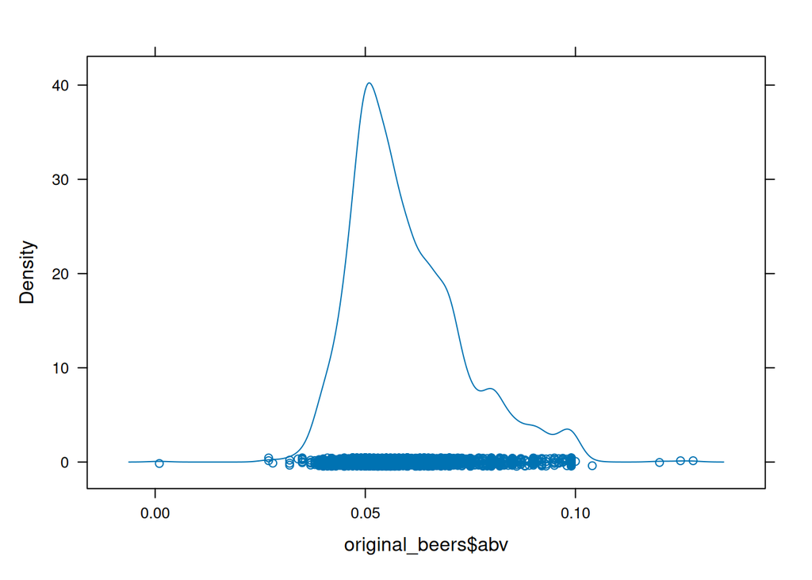

```r
densityplot(original_beers$abv)
```

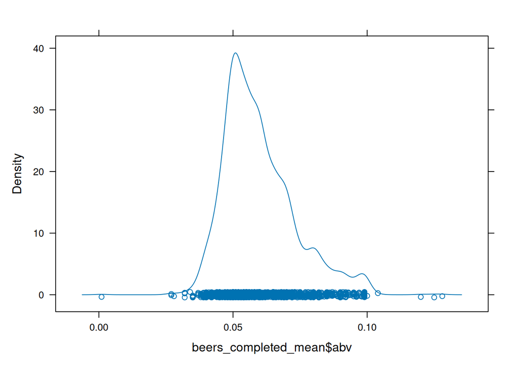

```r
densityplot(beers_completed_mean$abv)
```

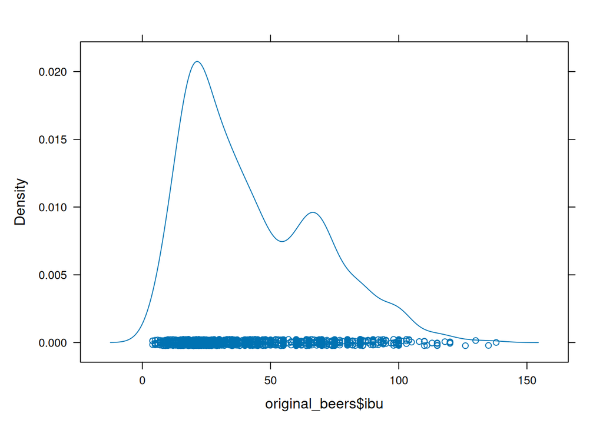

```r
densityplot(original_beers$ibu)
```

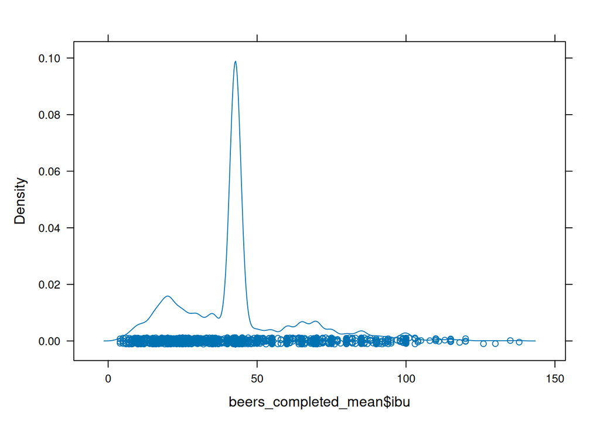

```r
densityplot(beers_completed_mean$ibu)
```

Probaremos otro método de imputación:

# Imputación de datos con distribución normal

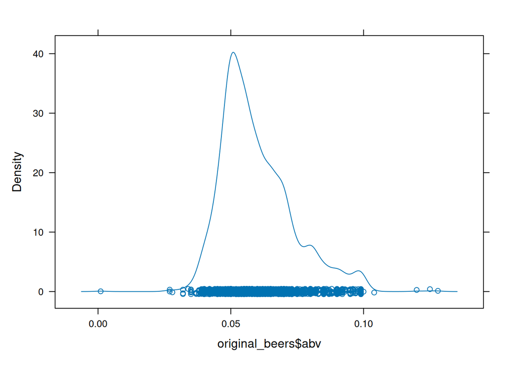

```r
densityplot(original_beers$abv)
```

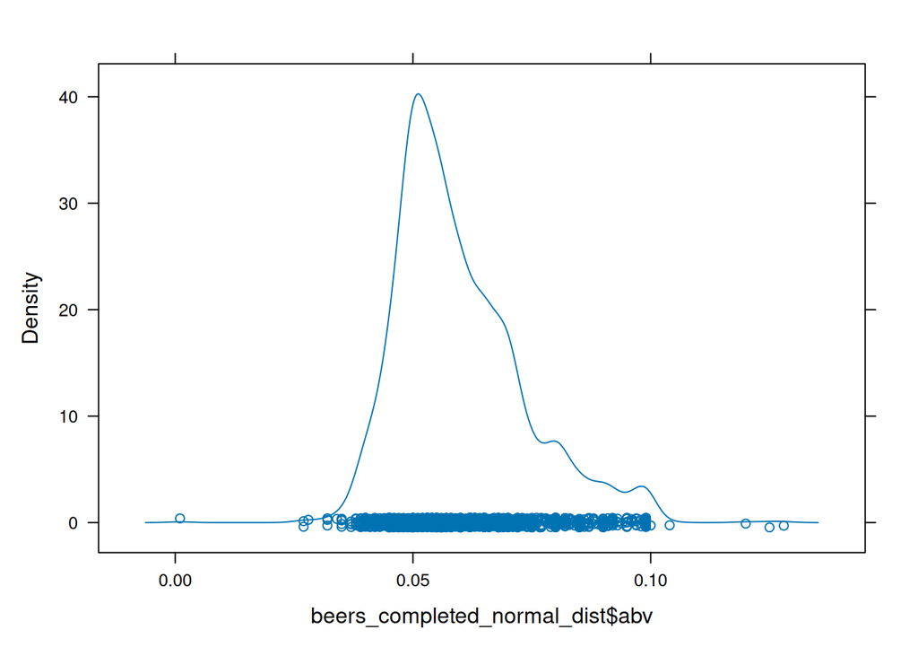

```r
densityplot(beers_completed_normal_dist$abv)
```

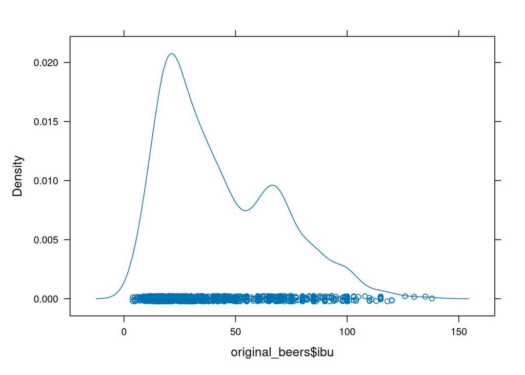

```r
densityplot(original_beers$ibu)
```

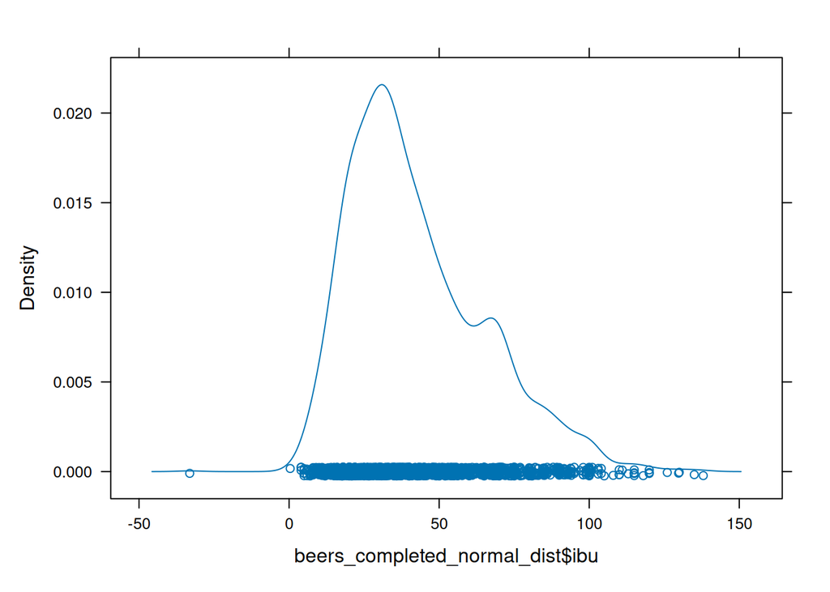

```r
densityplot(beers_completed_normal_dist$ibu)
```

Ahora obtenemos datos completados con una distribución coherente con los datos originales.